# [회고] tqk 업데이트 수정 종가 반영 및 param 조정

R

tqk

adjusted

announce

tqk 패키지를 버전업하면서 배운 점을 작성해보았습니다.

true  
2018-11-22

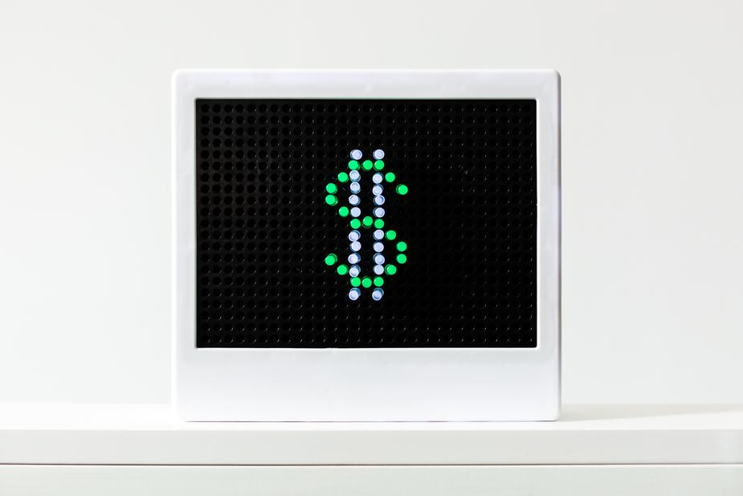

이번 0.1.0 버전 업데이트는 다음 소스 추가로 인한 속도 향상 및 수정주가 반영입니다. 거기에 `tq_get()`함수를 모방하기로 한 주제에 **param** 설계가 달라서 맞춰주는 작업을 수행했습니다.

### 배운 점

새롭게 json을 처리하면서 `purrr::transpose()`, `dplyr::select_if()`를 알게 되었습니다. json을 `tibble::as_tibble()` 로 처리한 후 `tidyr::unnest()` 시 발생하는 문제의 원인을 알게 되었습니다.

#### `tibble`자료형과 `as_tibble()` 함수

`tibble`, `tbl` 자료형은 현대적인 R을 사용하는데 근간이 되는 자료형입니다. base R의 `data.frame`의 현대적 버전이라고 할 수 있는데요. 매우 많은 장점이 있습니다.

우선 `dim()`, `head()`, `class()` 개별 컬럼의 `class()`가 객체를 출력하는 것으로 한번에 해결됩니다. 출력량도 화면에 기반하여 제한하고 있어서, 많은 출력으로 멈추거나 하는 문제를 사전에 방지하고 있습니다. 좀 불편하다면, 컬럼도 출력 제한을 한다는 점 정도 인데요.

보통 `matrix` 나 `data.frame`을 `tibble` 자료형으로 바꾸려면 `as_tibble()` 함수를 사용합니다. `json`으로 들어온 `list`는 웹 데이터를 다룰 때 많이 겪게 되는데요. 2단 구조의 `list`일 때 `as_tibble()`이 동작한다면 아주 편할 것 같습니다.

예를 들어 보겠습니다.

```r
col_first_list <- list(a = list(1, 2, 3), b = list(4, 5, 6))
col_first_list
```

```
$a
$a[[1]]
[1] 1

$a[[2]]
[1] 2

$a[[3]]
[1] 3


$b
$b[[1]]
[1] 4

$b[[2]]
[1] 5

$b[[3]]
[1] 6
```

2단 구조를 만들 때 헷갈리지 않기 위해서 1단은 이름을 지어서, 2단은 이름없이 2단 `list`를 만들었습니다. 간단히 대응하면 1,2,3 데이터를 가지는 **a** 컬럼과 4,5,6 데이터를 가지는 **b** 컬럼의 table일 수 있을 것 같습니다. 컬럼 단위로 묶어서 데이터를 보냈으므로, 저는 **col_first_list**라고 이름지어 봤습니다.

```r
library(dplyr)
col_first_list %>%
    tibble::as_tibble()
```

```
# A tibble: 3 x 2
  a         b
  <list>    <list>
1 <dbl [1]> <dbl [1]>
2 <dbl [1]> <dbl [1]>
3 <dbl [1]> <dbl [1]>
```

음… `tibble`로는 된거 같은데, 뭔가 이상합니다. 찾아보니 `tibble`은 컬럼의 자료형이 `list`가 가능하더라구요. 그럼 평소에 알고 있는 모습으로 바꾸는 작업이 필요할 것 같습니다.

#### 새롭게 배운 함수 1 `tidyr::unnest()`

```
Nest and unnest

Description
Nesting creates a list-column of data frames; unnesting flattens it back out into regular columns. Nesting is implicitly a summarising operation: you get one row for each group defined by the non-nested columns. This is useful in conjunction with other summaries that work with whole datasets, most n…

Learn more in vignette("nest").

Usage
nest(.data, ..., .key = deprecated())

unnest(data, cols, ..., keep_empty = FALSE, ptype = NULL,
  names_sep = NULL, names_repair = "check_unique",
  .drop = deprecated(), .id = deprecated(), .sep = deprecated(),
  .preserve = deprecated())
```

제목과 설명을 보면 딱 필요한 함수 같아 보입니다. 한번 사용해 볼까요?

```r
col_first_list %>%
  tibble::as_tibble() %>%
  tidyr::unnest()
```

```
# A tibble: 3 x 2
      a     b
  <dbl> <dbl>
1     1     4
2     2     5
3     3     6
```

깔끔하게 결과가 나왔습니다.

하지만 보통 json을 웹서비스에서 받을 때 반대로 되어 있는 경우가 많습니다.

```r
row_first_list <- list(list(a = 1, b = 4), list(a = 2, b = 5), list(a = 3, b = 6))
row_first_list
```

```
[[1]]
[[1]]$a
[1] 1

[[1]]$b
[1] 4


[[2]]
[[2]]$a
[1] 2

[[2]]$b
[1] 5


[[3]]
[[3]]$a
[1] 3

[[3]]$b
[1] 6
```

```r
row_first_list %>%
    tibble::as_tibble()
```

```
Error: Columns 1, 2, and 3 must be named.
```

우선 `tibble::as_tibble()`이 바로 처리 해주지를 못합니다. 컬럼은 이름이 있어야만 한다는 군요. 이때 `purrr::transpose()` 가 필요합니다.

#### 새롭게 배운 함수 2 `purrr::transpose()`

```
Transpose a list.

Description
Transpose turns a list-of-lists "inside-out"; it turns a pair of lists into a list of pairs, or a list of pairs into pair of lists. For example, if you had a list of length n where each component had values a and b, transpose() would make a list with elements a and b that contained lists of length n…

Usage
transpose(.l, .names = NULL)
```

```r
row_first_list %>%
    purrr::transpose() %>%
    tibble::as_tibble() %>%
    tidyr::unnest()
```

```
# A tibble: 3 x 2
      a     b
  <dbl> <dbl>
1     1     4
2     2     5
3     3     6
```

이렇게 2단 으로 구성된 json 파일은 쉽게 `tibble` 자료형으로 고쳐서 R에서 다룰수 있습니다.

#### `tidyr::unnest()` 함수의 문제점

```r
includ_null <- list(a = list(1, 2, 3), b = list(4, NULL, 6.5))
includ_null %>%
  tibble::as_tibble()
```

```
# A tibble: 3 x 2
  a         b
  <list>    <list>
1 <dbl [1]> <dbl [1]>
2 <dbl [1]> <NULL>
3 <dbl [1]> <dbl [1]>
```

```r
includ_null %>%
  tibble::as_tibble() %>%
  tidyr::unnest()
```

```
# A tibble: 3 x 2
      a     b
  <dbl> <dbl>
1     1   4
2     2  NA
3     3   6.5
```

또 전체가 `null`인 컬럼도 있으면 안됩니다.

```r
all_null <- list(a = list(1, 2, 3), b = list(NULL, NULL,NULL))
all_null %>%
  tibble::as_tibble()
```

```
# A tibble: 3 x 2
  a         b
  <list>    <list>
1 <dbl [1]> <NULL>
2 <dbl [1]> <NULL>
3 <dbl [1]> <NULL>
```

```r
all_null %>%
  tibble::as_tibble() %>%
  tidyr::unnest()
```

```
Error: `b` must be a data frame column
```

이 두 가지는 다른 처리방법을 사용해야 할 것 같습니다. 전체가 `null`인 컬럼은 제거하고, 일부가 `null`인 컬럼은 `null`을 다른 값으로 대체해야 겠네요. 전체가 `null`인 컬럼 이름을 하드코딩할 수도 있겠지만, 찾아서 제거하는 것이 더 좋아보였습니다.